# Rapid specification of random tabular datasets generation in R

Anton Antonov

2020-12-28

````r
```r
library(dplyr)
````

[output not shown]

[output not shown]

[output not shown]

[output not shown]

[output not shown]

[output not shown]

[output not shown]

[output cut: 72 more lines]

[output not shown]

[output not shown]

| Creature | BodyWeight | BrainWeight |
| --- | --- | --- |
| ODZI | 13.7 | 155.0 |
| fQMB | 5.7 | 14.4 |
| zGrssQ | 3.7 | 5.1 |
| p | 7.1 | 7.2 |
| tRmT | 623.0 | 474.5 |
| vRBL | 406.0 | 1307.9 |
| Ld | 25.3 | 46.1 |
| trsmi | 125.2 | 611.9 |
| n | 20.2 | 23.9 |
| PD | 11823.0 | 23313.8 |

[output cut: 7 more lines]

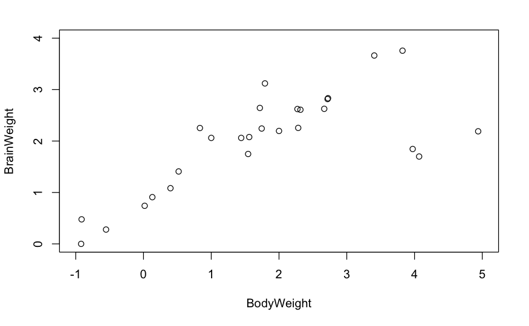

```r
plot(log10(dfAW[,c(2,3)]), xlim=c(-1,5), ylim=c(0,4))
```

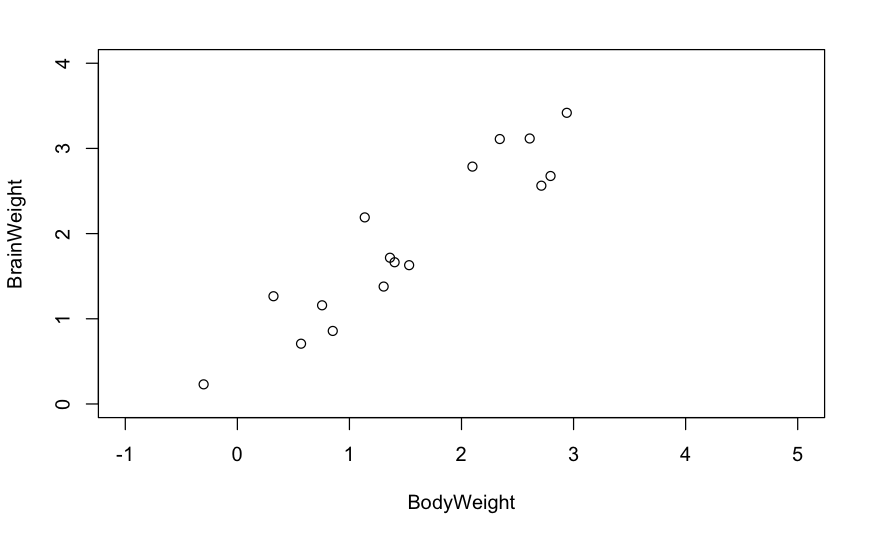

```r
plot(log10(dfCW[,c(2,3)]), xlim=c(-1,5), ylim=c(0,4))
```

**Remark:** In Mathematica/WL instead of quartile boundaries filtering we can filter with `AnomalyDetection[Normal[dsAW[All, #BrainWeight/#BodyWeight &]]]`, but the latter is prone to produce results that are “too far off.”

# Neat example

Here is a random data frame with 10 rows, column names that generated with `RandomWord`, column values generated by with alternating numerical and string generators, and specified minimum of non-missing values:

````r
```r
set.seed(652)
RandomDataFrame(
  nrow = 10,
  columnNamesGenerator = RandomWord,
  generators = c(runif, RandomString, rnorm),
  minNumberOfValues = 40)
````

[output not shown]

## Applications to data obfuscation

A more rigorous and enhanced version of the random dataset generation example in the section “Demonstration” above can be utilized to do data obfuscation that:

- Allows easier to specify obfuscation elements and features
- Produces data that is harder to identify as an obfuscated version of the original data

See the related R packages [“fakeR”](https://cran.r-project.org/web/packages/fakeR/index.html), [LZ1], and [“DataObfuscation”](https://github.com/antononcube/R-packages/tree/master/DataObfuscation), [AAp3].

## Implementations in Julia, Python, R, and WL

These four languages – Julia, Python, R, and WL – are the target languages of the Domain Specific Language (DSL) [Raku](https://raku.org) module [[AAr1](https://github.com/antononcube/Raku-DSL-English-DataQueryWorkflows)] that allows the generation of programming code through natural language commands.

It is natural to consider the implementation of `RandomTabularDataset` or `RandomDataFrame` in all four programming languages. Especially, if we take into account that:

- Both R and WL have intimate integration with Python
- Julia, R, and WL have many design and usage similarities (since they are descendants of LISP)

## Implementing the more general `RandomDataset`

As it was mentioned above, in Mathematica / WL datasets can be (deeply) hierarchical objects. Tabular datasets (data frames) are simpler than the general WL datasets, but tabular data is very common, easier to explain and to reason with. Hence, `RandomTabularDataset` is a 2D specialization of much more ambitious function: `RandomDataset`.

A few immediate observations:

- We can make a `RandomDataset` object making a WL associations of `RandomTabularDataset` objects
- We have to “scale” the generators to generate not just random points or vectors but also random multi-dimensional arrays.

From the observations follows that `RandomDataset` should have most of the arguments and options of `RandomTabularDataset`, but there two main questions that require careful design answers:

- How to specify generators that correspond to k-dimensional arrays (with k > 1)?
- How to specify generators that for names of particular arrays in particular dimensions?

## Conversational agent for generating random objects

I consider making a conversational agent that generates programming code (in R, WL, others) that generate random objects.

**Remark:** The conversational agent targets not just the generation of random tabular datasets but any random objects that can be generated in R and WL.

Here are example commands:

```
make a list of 24 random graphs
```

```
make twenty random datasets with columns that are normally distributed
each dataset should have at least 200 rows and at least 5 columns
```

```
make a random dataset with first column made of random words and second column with Poisson distribution numbers with lambda 3
```

The design of the conversational agent has to use both appropriate grammars and well defined graph of Finite State Machine (FSM) transitions. (Grammars, of course, themselves can be seen as FSMs. Hence, can be included in the master FSM.)

# References

### Articles, posts

[MB1] Mike Besso, [“Creating Random Datasets”](https://community.wolfram.com/groups/-/m/t/2109909), (2020), community.wolfram.com.

[AA1] Anton Antonov, [“Data transformation workflows - Wolfram U sessions”](https://community.wolfram.com/groups/-/m/t/2112820), (2020), community.wolfram.com.

[AA2] Anton Antonov, [“A monad for Quantile Regression workflows”](https://mathematicaforprediction.wordpress.com/2018/08/01/a-monad-for-quantile-regression-workflows/), (2018), [MathematicaForPrediction at WordPress](https://mathematicaforprediction.wordpress.com).

[AA3] Anton Antonov, [“Rapid specification of random tabular datasets generation”](https://github.com/antononcube/MathematicaForPrediction/blob/master/MarkdownDocuments/Rapid-specification-of-random-tabular-datasets-generation.md), (2020), [MathematicaForPrediction at GitHub/antononcube](https://github.com/antononcube).

### Packages, repositories

[LZ1] Lily Zhang and Dustin Tingley, [“fakeR: Simulates Data from a Data Frame of Different Variable Types”](https://cran.r-project.org/web/packages/fakeR/index.html) (2016), [CRAN](https://cran.r-project.org).

[TR1] Tyler Rinker et al., [“wakefield: Generate Random Data Sets”](https://cran.r-project.org/web/packages/wakefield/index.html), (2020), [CRAN](https://cran.r-project.org).

[AAp1] Anton Antonov, [Random Tabular Dataset Mathematica Package](https://github.com/antononcube/MathematicaForPrediction/blob/master/Misc/RandomTabularDataset.m), (2020), [MathematicaForPrediction at GitHub/antononcube](https://github.com/antononcube/MathematicaForPrediction).

[AAp2] Anton Antonov, [RandomTabularDataset Mathematica unit tests](https://github.com/antononcube/MathematicaForPrediction/blob/master/UnitTests/RandomTabularDataset-Unit-Tests.wlt), (2020), [MathematicaForPrediction at GitHub/antononcube](https://github.com/antononcube/MathematicaForPrediction).

[AAp3] Anton Antonov, [“Data obfuscation functions in R”](https://github.com/antononcube/R-packages/tree/master/DataObfuscation), (2019), [R-packages at GitHub/antononcube](https://github.com/antononcube/R-packages).

[AAp4] Anton Antonov, [Monadic Event Records Transformations Mathematica package](https://github.com/antononcube/MathematicaForPrediction/blob/master/MonadicProgramming/MonadicEventRecordsTransformations.m), (2018), [MathematicaForPrediction at GitHub/antononcube](https://github.com/antononcube/MathematicaForPrediction).

[AAp5] Anton Antonov, [“Random Data Frame Generator in R”](https://github.com/antononcube/R-packages/tree/master/RandomDataFrameGenerator), (2020), [R-packages at GitHub/antononcube](https://github.com/antononcube/R-packages).

[AAr1] Anton Antonov, [DSL::English::DataQueryWorkflows Raku package](https://github.com/antononcube/Raku-DSL-English-DataQueryWorkflows), (2020), [Raku-DSL-English-DataQueryWorkflows at GitHub/antononcube](https://github.com/antononcube/Raku-DSL-English-DataQueryWorkflows).

[AAr2] Anton Antonov, [“Event Records Transformations Monad in R”](https://github.com/antononcube/ERTMon-R), (2018), [ERTMon-R at GitHub/antononcube](https://github.com/antononcube/ERTMon-R).

[AAr3] Anton Antonov, [“Quantile Regression Monad in R”](https://github.com/antononcube/QRMon-R), (2019), [QRMon-R at GitHub/antononcube](https://github.com/antononcube/QRMon-R).

## Wolfram Functions Repository

[AAw1] Anton Antonov RandomTabularDataset.

[AAw2] Anton Antonov ExampleDataset.